# Lecture 40: Preconditioning

Preconditioning is a simple, general idea that can require a lot of explanation in practice. Since the convergence of a Krylov method depends (at least) on the spectral properties of the matrix, we can improve the convergence by transforming to an equivalent problem with a different matrix. Specifically, $Ax=b$ becomes $M^{-1}Ax=M^{-1}b$ for some matrix $M$. We don't typically plug in $M^{-1}$; rather we have to solve a system $Mv=u$ whenever we would want $M^{-1}u$. In essence, $M$ should be an "easily inverted" approximation of $A$.

We'll experiment with the 5-point difference representation of the Laplacian operator on a square.

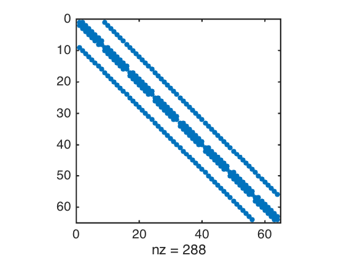

```matlab
del2 = @(n) n^2*delsq( numgrid('S',n) );
spy(del2(10));
```

As is usually the case in PDEs, the conditioning of $A$ gets worse as the discretization gets better. (After all, the eigenvalues of the exact operator are unbounded.)

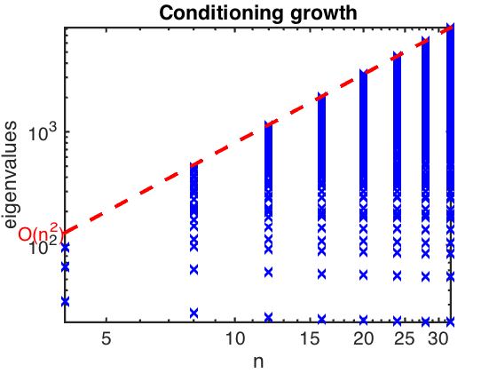

```matlab
for n = 4:4:32
  lambda = eig( full(del2(n)) );
  loglog(n,lambda,'bx'),  hold on
end
plot(4:32,8*(4:32).^2,'r--')
text(4,130,'O(n^2)','color','red','horiz','r')
title('Conditioning growth')
xlabel('n')
ylabel('eigenvalues')
axis tight
```

Here's what we get applying CG to this matrix at $n=160$. (We're plotting the solution of the Poisson equation, $\Delta u=-1$.)

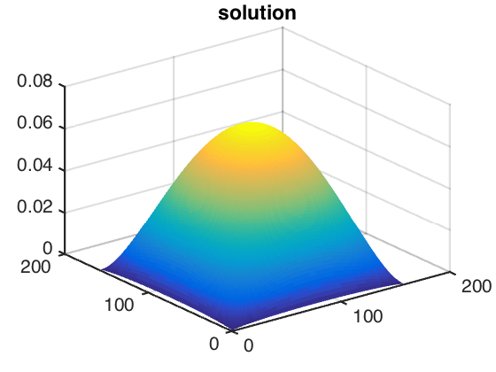

```matlab
n = 160;
A = del2(n);  b = ones(length(A),1);
[x,flag,rr,iter,rvec] = pcg(A,b,1e-8,250);
surf( reshape(x,n-2,n-2) )
title('solution')
shading flat
```

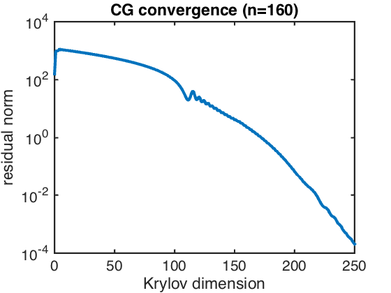

```matlab
semilogy(0:length(rvec)-1,rvec)
xlabel('Krylov dimension'), ylabel('residual norm')
title('CG convergence (n=160)')
```

A simple preconditioner might be to strip away the nonzeros of $A$ that are wider than the tridiagonal strip. This $M$ is easier to invert/solve than the original $A$.

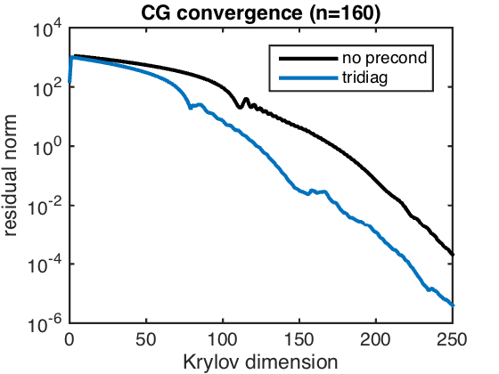

```matlab
M = spdiags( spdiags(A,-1:1), -1:1, length(A), length(A));
[x,flag,rr,iter,rvecT] = pcg(A,b,1e-8,250,M);

semilogy(0:length(rvec)-1,rvec,'k')
hold on
semilogy(0:length(rvecT)-1,rvecT)
legend('no precond','tridiag')
xlabel('Krylov dimension'), ylabel('residual norm')
title('CG convergence (n=160)')
```

A more sophisticated strategy is the *incomplete Cholesky factorization*. There are various forms; here, we compute a Cholesky factor but zero out any elements that are zero in the same location in $A$.

```matlab
R = ichol(A);
fprintf(' %i nonzeros in A; %i nonzeros in M\n\n',nnz(A),nnz(R))
```

```
124188 nonzeros in A; 74576 nonzeros in M
```

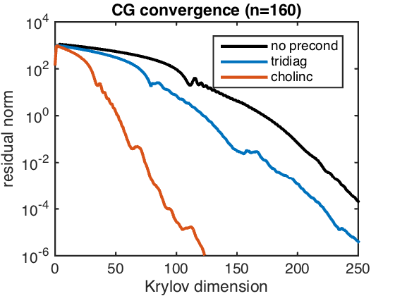

```matlab
[x,flag,rr,iter,rvecI] = pcg(A,b,1e-8,250,R',R);
semilogy(0:length(rvec)-1,rvec,'k')
hold on
semilogy(0:length(rvecT)-1,rvecT)
semilogy(0:length(rvecI)-1,rvecI)
legend('no precond','tridiag','cholinc')
xlabel('Krylov dimension'), ylabel('residual norm')
title('CG convergence (n=160)')
```

In a sense this looks successful, but in fact the number of iterations would still grow as a function of $n$.

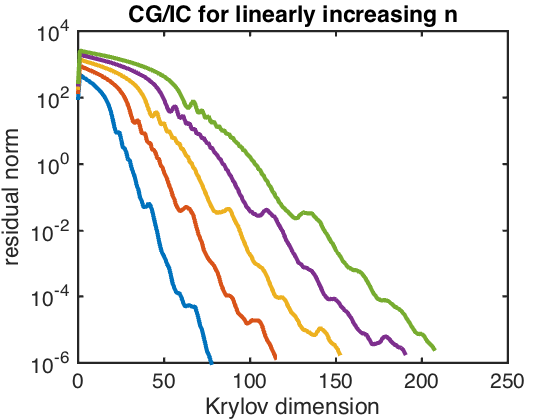

```matlab
for n = 100:50:300
    A = del2(n);  b = ones(length(A),1);
    R = ichol(A);
    [x,flag,rr,iter,rvec] = pcg(A,b,1e-8,250,R',R);
    semilogy(0:length(rvec)-1,rvec)
    hold on
end
xlabel('Krylov dimension'), ylabel('residual norm')
title('CG/IC for linearly increasing n')
ylim([1e-6 1e4])
```

In scientific computation a good preconditioner would keep the number of iterations well under 50 for large $n$. This usually requires detailed understanding and exploitation of the underlying problem, unlike the purely algebraic approach taken here.